# DTSA 5509 Introduction to Machine Learning - Supervised Learning

Final Report - Deliverable 1

Author

Andrew Simms

Published

March 7, 2023

# 1 Problem Description

This project aims to develop the most accurate pricing model for real estate listings in my local area. We plan to pull data from [Zillow](https://zillow.com) using the `GetSearchPageState` api. This data will be filtered and cleaned using knowledge of the local real estate market. As real estate prices are floating point values we will use multiple regression modeling techniques from simple to complex and compare the results. Using the best performing model we will predict real estate listing prices on new data. The ultimate goal is to find listings that may be undervalued (“good deals”) vs comparable listings. All files used to create this project can be found here https://github.com/simmsa/dtsa5509_final.

To narrow down the listings, and make the result more relevant for the author, this document focuses on real estate listings in the Denver Colorado metropolitan area.

In Figure 1 we outline the steps necessary to reach our goal of predicting the price of a real estate listing.

```
%%{
  init: {
    'theme': 'base',
    'themeVariables': {
      'primaryColor': '#E1F5FE',
      'primaryTextColor': '#111',
      'fontFamily': '-apple-system, BlinkMacSystemFont, Roboto, Oxygen, Ubuntu, Cantarell, sans-serif',
      'fontSize': '14px'
    }
  }
}%%

flowchart LR
    A(Data Cleaning / Wrangling) --> B(Imputation)
    B --> C(Correlation Analysis)
    C --> D(Data Filtering / Optimization)
    D --> E(Optimized SF Linear Regression)
    D --> F(Forward Selection)
    D --> G(AdaBoostRegressor)
    D --> H(XGBRegressor)
    E --> I(Analysis)
    F --> I
    G --> I
    H --> I
    I --> J(Price Prediction)
```

Figure 1: Regression Model Testing Flow Chart

# 2 Exploratory Data Analysis (EDA) Procedure

## 2.1 Data Acquisition

Data is acquired using [`scraper.py`](https://github.com/simmsa/dtsa5509_final/blob/main/scraper.py) python script and formatted with the [`formatter.py`](https://github.com/simmsa/dtsa5509_final/blob/main/formatter.py) python script. This script interfaces with the [Zillow.com](https://www.zillow.com) `GetSearchPageState` API and downloads data by zip code for the included zip codes. The initial format of the data is a `json` file with 6776 real estate listing entries with each row consisting of 91 columns. For further processing we convert this file using `formatter.py` into a single `csv` file which is read into a pandas `DataFrame` object. The initial data is shown using `df.info()` as executed below:

```python
import pandas as pd

df = pd.read_csv("2023_03_04-12_38_22_unique_denver_area.csv")
df.info()
```

```
<class 'pandas.core.frame.DataFrame'>
RangeIndex: 6052 entries, 0 to 6051
Data columns (total 86 columns):
 #   Column                                               Non-Null Count  Dtype
---  ------                                               --------------  -----
 0   Unnamed: 0                                           6052 non-null   int64
 1   zpid                                                 6052 non-null   int64
 2   price                                                6052 non-null   object
 3   priceLabel                                           6052 non-null   object
 4   beds                                                 5077 non-null   float64
 5   baths                                                5140 non-null   float64
 6   area                                                 5103 non-null   float64
 7   statusType                                           6052 non-null   object
 8   statusText                                           6052 non-null   object
 9   isFavorite                                           6052 non-null   bool
```

[output cut: 78 more lines]

The output above shows that we are working with 6052 rows and 86 columns.

## 2.2 Data Wrangling / Cleaning

For input into our models we need to clean the data. As a first step we should remove columns (features) with large numbers of null values. For this we can set a threshold and use the `dropna` method

```python
drop_threshold = int(
    0.8 * len(df)
)  # Drop columns with more than the threshold percentage of null values
df = df.dropna(axis=1, thresh=drop_threshold)
print(len(df.columns))
```

```
59
```

## 2.3 Listing Types

There are multiple types of real estate listings in the data:

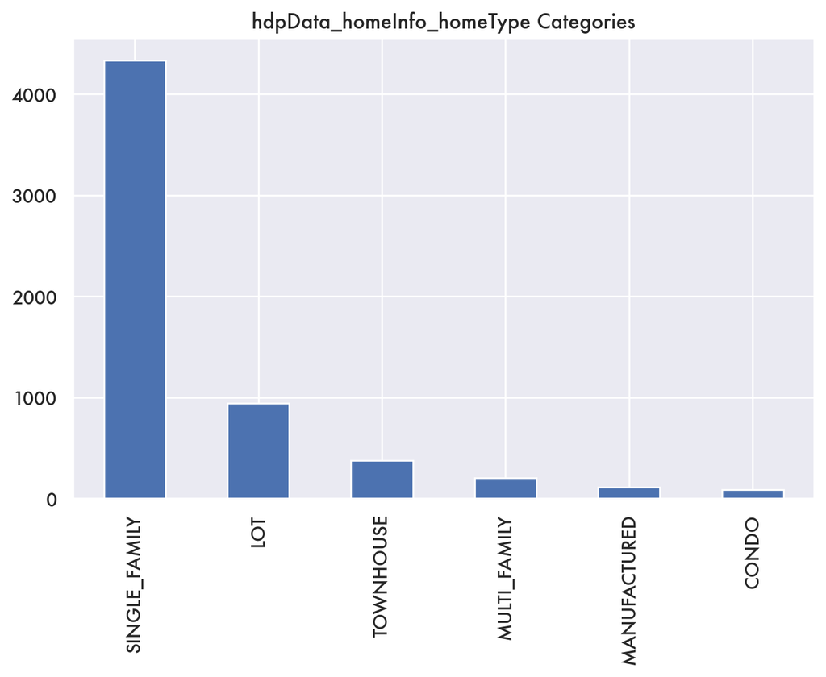

```python
import seaborn as sns
import matplotlib.pyplot as plt

sns.set_theme(style="white")
sns.set(font="Futura")
sns.set(rc={"figure.figsize": (8, 5)}, font="Futura")

df["hdpData_homeInfo_homeType"].value_counts().plot(kind="bar")
plt.title("hdpData_homeInfo_homeType Categories")
plt.show()
```

This shows that a large amount of the data are `SINGLE_FAMILY` listings. We would like to build models for listings that are similar, therefore we are going to filter the dataset to show only `SINGLE_FAMILY` type listings:

```python
df = df[df['hdpData_homeInfo_homeType'] == 'SINGLE_FAMILY']
```

## 2.4 Filtering

To tighten up our dataset let’s filter out listings with larger than 10,000 square and cost more than $10,000,000. In this specific real estate market we can also safely filter out listings that are smaller that 750 sqft and listings less that $200,000

```python
df = df[(df['hdpData_homeInfo_price'] < 10_000_000) & (df['hdpData_homeInfo_price'] > 200_000)]
df = df[(df['area'] < 10_000) & (df['area'] > 750)]
```

## 2.5 Imputation

Each model has different requirements for the values that are input into the model. To provide a fair comparison between models we are going to pass the same data to all models. First we are going to impute the missing values. Then we are going to create multiple `DataFrame` that contain specific data types. Linear regression models including single feature linear regression, multi feature linear regression and forward selection work best with numbers. `AdaBoostRegressor` will work with numbers and boolean values. `XGBRegressor` is the most flexible, but we will pass the same data as `AdaBoostRegressor`

We will use `KNNImputer` to impute the missing values:

```python
from sklearn.impute import KNNImputer


def impute_df(input_df):
    imputer = KNNImputer()
    columns = input_df.columns
    input_df = pd.DataFrame(imputer.fit_transform(input_df))
    input_df.columns = columns
    return input_df


number_df = df.select_dtypes(["number"])
number_df = impute_df(number_df)

number_df.info()
```

```
<class 'pandas.core.frame.DataFrame'>
RangeIndex: 4220 entries, 0 to 4219
Data columns (total 20 columns):
 #   Column                             Non-Null Count  Dtype
---  ------                             --------------  -----
 0   Unnamed: 0                         4220 non-null   float64
 1   zpid                               4220 non-null   float64
 2   beds                               4220 non-null   float64
 3   baths                              4220 non-null   float64
 4   area                               4220 non-null   float64
 5   latLong_latitude                   4220 non-null   float64
 6   latLong_longitude                  4220 non-null   float64
 7   hdpData_homeInfo_zpid              4220 non-null   float64
 8   hdpData_homeInfo_zipcode           4220 non-null   float64
 9   hdpData_homeInfo_latitude          4220 non-null   float64
 10  hdpData_homeInfo_longitude         4220 non-null   float64
 11  hdpData_homeInfo_price             4220 non-null   float64
 12  hdpData_homeInfo_bathrooms         4220 non-null   float64
 13  hdpData_homeInfo_bedrooms          4220 non-null   float64
 14  hdpData_homeInfo_livingArea        4220 non-null   float64
 15  hdpData_homeInfo_daysOnZillow      4220 non-null   float64
 16  hdpData_homeInfo_priceForHDP       4220 non-null   float64
 17  hdpData_homeInfo_taxAssessedValue  4220 non-null   float64
 18  hdpData_homeInfo_lotAreaValue      4220 non-null   float64
 19  lot_sqft                           4220 non-null   float64
dtypes: float64(20)
memory usage: 659.5 KB
```

```python
bool_df = df.select_dtypes(["bool"])
bool_df = impute_df(bool_df)
bool_df.info()
```

```
<class 'pandas.core.frame.DataFrame'>
RangeIndex: 4220 entries, 0 to 4219
Data columns (total 17 columns):
 #   Column                                    Non-Null Count  Dtype
---  ------                                    --------------  -----
 0   isFavorite                                4220 non-null   float64
 1   isUserClaimingOwner                       4220 non-null   float64
 2   isUserConfirmedClaim                      4220 non-null   float64
 3   visited                                   4220 non-null   float64
 4   shouldShowZestimateAsPrice                4220 non-null   float64
 5   has3DModel                                4220 non-null   float64
 6   hasVideo                                  4220 non-null   float64
 7   isHomeRec                                 4220 non-null   float64
 8   hasAdditionalAttributions                 4220 non-null   float64
 9   isFeaturedListing                         4220 non-null   float64
 10  hdpData_homeInfo_isFeatured               4220 non-null   float64
 11  hdpData_homeInfo_shouldHighlight          4220 non-null   float64
 12  hdpData_homeInfo_isUnmappable             4220 non-null   float64
 13  hdpData_homeInfo_isPreforeclosureAuction  4220 non-null   float64
 14  hdpData_homeInfo_isNonOwnerOccupied       4220 non-null   float64
 15  hdpData_homeInfo_isPremierBuilder         4220 non-null   float64
 16  hdpData_homeInfo_isZillowOwned            4220 non-null   float64
dtypes: float64(17)
memory usage: 560.6 KB
```

```python
bool_df = bool_df.astype('bool')
bool_df.info()
```

```
<class 'pandas.core.frame.DataFrame'>
RangeIndex: 4220 entries, 0 to 4219
Data columns (total 17 columns):
 #   Column                                    Non-Null Count  Dtype
---  ------                                    --------------  -----
 0   isFavorite                                4220 non-null   bool
 1   isUserClaimingOwner                       4220 non-null   bool
 2   isUserConfirmedClaim                      4220 non-null   bool
 3   visited                                   4220 non-null   bool
 4   shouldShowZestimateAsPrice                4220 non-null   bool
 5   has3DModel                                4220 non-null   bool
 6   hasVideo                                  4220 non-null   bool
 7   isHomeRec                                 4220 non-null   bool
 8   hasAdditionalAttributions                 4220 non-null   bool
 9   isFeaturedListing                         4220 non-null   bool
 10  hdpData_homeInfo_isFeatured               4220 non-null   bool
 11  hdpData_homeInfo_shouldHighlight          4220 non-null   bool
 12  hdpData_homeInfo_isUnmappable             4220 non-null   bool
 13  hdpData_homeInfo_isPreforeclosureAuction  4220 non-null   bool
 14  hdpData_homeInfo_isNonOwnerOccupied       4220 non-null   bool
 15  hdpData_homeInfo_isPremierBuilder         4220 non-null   bool
 16  hdpData_homeInfo_isZillowOwned            4220 non-null   bool
dtypes: bool(17)
memory usage: 70.2 KB
```

In this process we have made our target of `price` difficult to access. The original price was stored as a string in the dataset, with the floating point value stored in `hdpData_homeInfo_price`. We fix this in the code below:

```python
number_df = number_df.rename(columns={"hdpData_homeInfo_price": "price"})

number_df_raw = number_df
```

## 2.6 Removing Irrelevant Columns

Linear regression is highly sensitive to features that are correlated. Below we analyze the contents of `number_df`. Our goal is to remove columns that are duplicates and visualize the correlation between features.

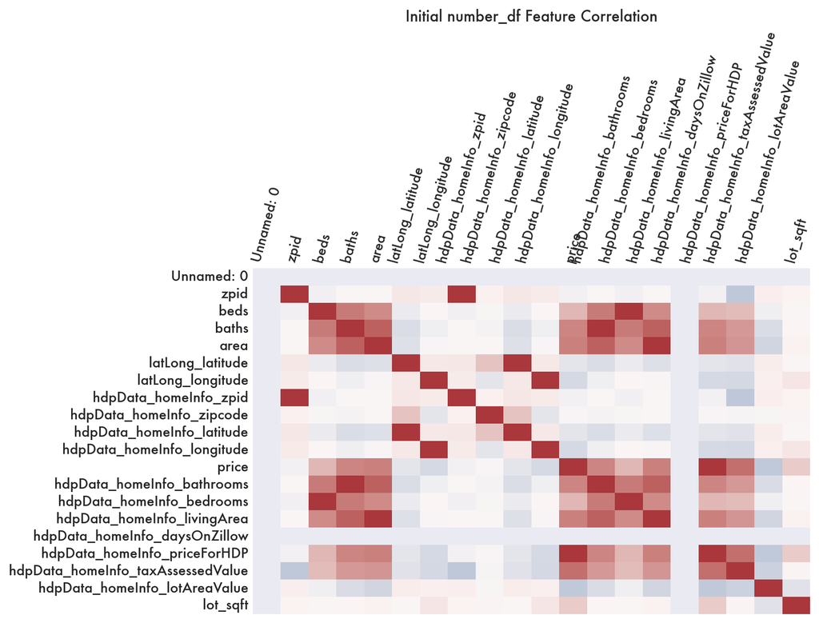

```python
def plot_correlation(input_df, title, annot=True, tick_rot=0):
    corr = input_df.corr()
    fig, ax = plt.subplots()
    sns.heatmap(
        corr,
        cmap="vlag",
        annot=annot,
        xticklabels=corr.columns,
        yticklabels=corr.columns,
        vmin=-1.0,
        vmax=1.0,
        fmt=".2f",
        cbar=False,
    ).set(title=title)
    ax.xaxis.tick_top()
    ax.tick_params(length=0)
    plt.xticks(rotation=tick_rot)
    plt.yticks(rotation=0)
    plt.show()


plot_correlation(number_df, "Initial number_df Feature Correlation", annot=False, tick_rot=75)
```

Looking at the above, there are features that are may negatively influence the regression calculation. For a more optimized model we need to remove the values that do not contain information that will help build a price prediction model. Below we remove unnecessary columns and cleanup the column names. Specifically we are removing numerical values that are unrelated to the price calculation of a listing, including the zip code, listing id (`zpid`), and the latitude and longitude. We are also removing the `taxAssesedValue` as this is similar to price and can influence the final pricing model.

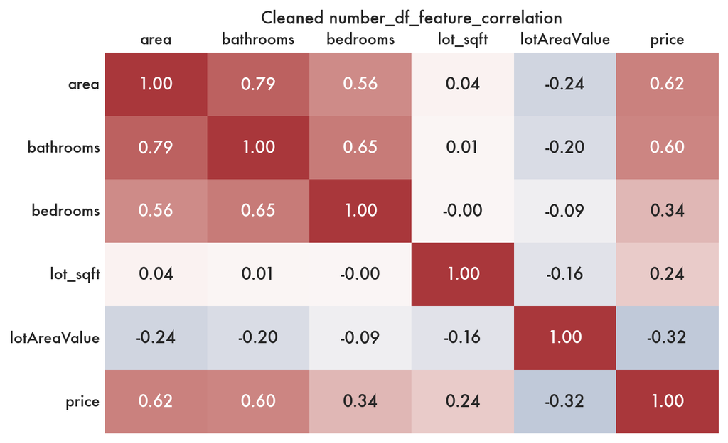

```python
number_df_corr = (
    number_df.corr()["price"].sort_values(ascending=False).drop_duplicates()
)
number_df_corr = number_df_corr.dropna()
number_df_corr = number_df_corr[lambda x: x != 1.0]

number_df_corr = number_df_corr.drop(
    [
        "hdpData_homeInfo_zipcode",
        "zpid",
        "hdpData_homeInfo_latitude",
        "latLong_longitude",
        "hdpData_homeInfo_livingArea",
        "hdpData_homeInfo_taxAssessedValue",
    ]
)

number_df = number_df[list(number_df_corr.index) + ["price"]]
number_df.columns = number_df.columns.str.replace(r"hdpData_homeInfo_", "")

number_bool_df = number_df.join(bool_df)

plot_correlation(number_df, "Cleaned number_df_feature_correlation")
```

Based on the above visualization, `lotAreaValue` is not strongly correlated to any other features. For now we will leave it in the data set as we do know if it will provide useful for other models.

## 2.7 Building Training and Test `DataFrame`s

Now that we have our data frames we can split them into training and test sets. Our target is going to be `price` and all other columns are going to be our features. We are using `train_test_split` to partition the data.

```python
from sklearn.model_selection import train_test_split

test_size = 0.2
random_state = 42

(
    lr_train,
    lr_test,
) = train_test_split(number_df, test_size=test_size, random_state=random_state)

target = "price"
```

## 2.8 Preparation for Model Comparison

To compare models we need to compute metrics for comparison. We have chosen to compute the mean squared error (MSE), the root mean squared error (RMSE), and $R^2$. As we are using the same dataset for all models we can safely use $R^2$ as a comparison. The code below calculates these values and saves them in `regression_model_stats` for comparison and visualization.

```python
from sklearn.metrics import mean_squared_error, r2_score, mean_absolute_percentage_error

regression_model_stats = {
    "Root Mean Squared Error": [],
    "$R^2$": [],
}


def calc_model_stats(name, i_y_test, i_y_pred):
    assert len(i_y_test) == len(
        i_y_pred
    ), "Test and prediction array lengths do not match!"

    calc_mean_squared_error = mean_squared_error(i_y_test, i_y_pred)
    calc_root_mean_squared_error = mean_squared_error(i_y_test, i_y_pred, squared=False)
    calc_mean_absolute_percentage_error = mean_absolute_percentage_error(
        i_y_test, i_y_pred
    )
    calc_r2_score = r2_score(i_y_test, i_y_pred)

    regression_model_stats["Root Mean Squared Error"].append(
        [name, calc_root_mean_squared_error]
    )
    regression_model_stats["$R^2$"].append([name, calc_r2_score])


def plot_model_stats(fig_width=12, fig_height=6):
    num_rows = 1
    num_cols = 2
    fig, axes = plt.subplots(
        nrows=num_rows, ncols=num_cols, figsize=(fig_width, fig_height)
    )

    iteration = 1
    for metric, values in regression_model_stats.items():
        labels = [x[0] for x in values]
        values = [x[1] for x in values]
        plt.subplot(num_rows, num_cols, iteration)
        p = plt.bar(labels, values)
        plt.title(f"{metric} by Model")
        if metric == "$R^2$":
            plt.bar_label(p, ["{:.4f}".format(x) for x in values])
        else:
            plt.bar_label(p, ["{:,}".format(int(x)) for x in values])
        plt.xticks(rotation=-45)
        iteration += 1

    plt.tight_layout()
    plt.show()
```

# 3 Single Feature Linear Regression

## 3.1 Initial OLS Single Feature Model

To build our single feature linear regression model we are using `statsmodels` ordinary least squares (OLS) linear regression functionality. Initially we are building our model using the feature with the highest correlation to `price`

```python
import statsmodels.formula.api as smf

feature = lr_train.corr()['price'].sort_values(ascending=False).index[1]

ols_model = smf.ols(formula=f"{target} ~ {feature}", data=lr_train)
result = ols_model.fit()

print(result.summary())
```

```
                            OLS Regression Results
==============================================================================
Dep. Variable:                  price   R-squared:                       0.367
Model:                            OLS   Adj. R-squared:                  0.367
Method:                 Least Squares   F-statistic:                     1959.
Date:                Tue, 07 Mar 2023   Prob (F-statistic):               0.00
Time:                        15:15:01   Log-Likelihood:                -50184.
No. Observations:                3376   AIC:                         1.004e+05
Df Residuals:                    3374   BIC:                         1.004e+05
Df Model:                           1
Covariance Type:            nonrobust
==============================================================================
                 coef    std err          t      P>|t|      [0.025      0.975]
------------------------------------------------------------------------------
Intercept  -1.509e+05   2.81e+04     -5.363      0.000   -2.06e+05   -9.57e+04
area         351.2351      7.937     44.255      0.000     335.674     366.796
==============================================================================
Omnibus:                     2943.620   Durbin-Watson:                   2.021
Prob(Omnibus):                  0.000   Jarque-Bera (JB):           112057.575
Skew:                           4.037   Prob(JB):                         0.00
Kurtosis:                      30.045   Cond. No.                     8.38e+03
==============================================================================

Notes:
[1] Standard Errors assume that the covariance matrix of the errors is correctly specified.
[2] The condition number is large, 8.38e+03. This might indicate that there are
strong multicollinearity or other numerical problems.
```

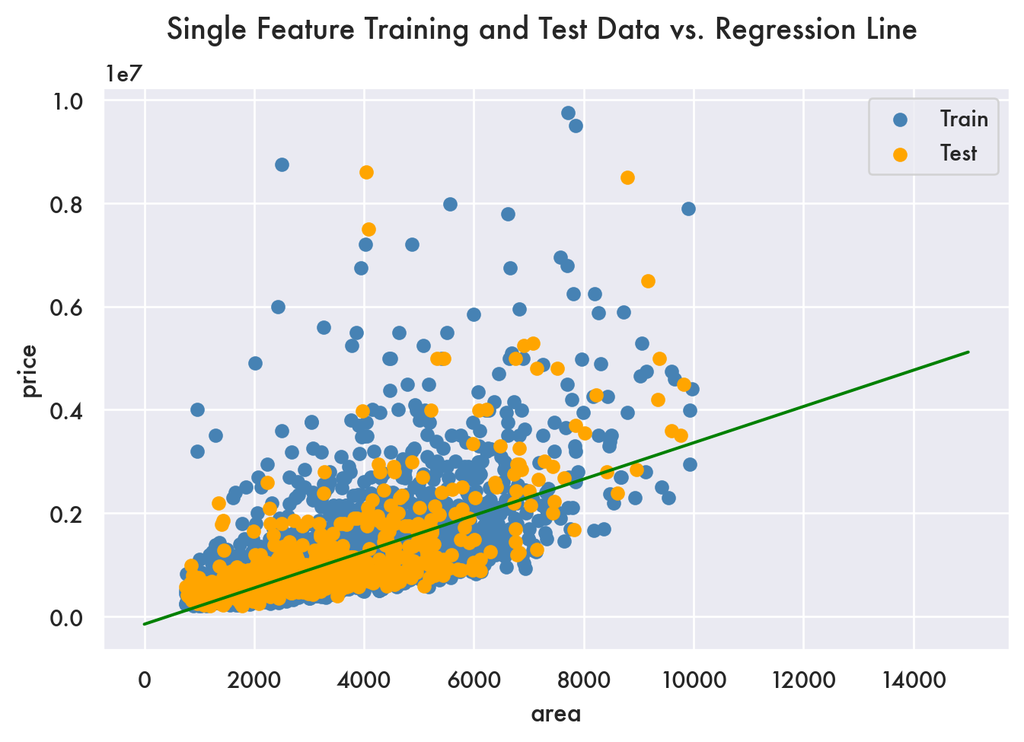

```python
params = dict(result.params)

plt.scatter(lr_train[feature], lr_train[target], color="steelblue", label="Train")
plt.scatter(lr_test[feature], lr_test[target], color="orange", label="Test")
x = range(0, 15000)
# Intentionally calculate the prediction for each X value
y = [((params[feature] * i) + params["Intercept"]) for i in x]
plt.plot(x, y, color="green")

# plt.suptitle(
#     f"Training Data: {target} against {feature}\n Slope: {params[feature]:.4f}, Intercept:{params['Intercept']:.4f}, $R^2$: {result.rsquared:.4f}"
# )
plt.suptitle(
        "Single Feature Training and Test Data vs. Regression Line"
)
plt.xlabel(feature)
plt.ylabel(target)
plt.legend()
plt.show()
```

This initial single feature model looks like a good start! There is a strong visual correlation between the regression line and the data. We can see that the test and training data look similar. We can start to calculate some statistics on the output of the model for comparison with other models:

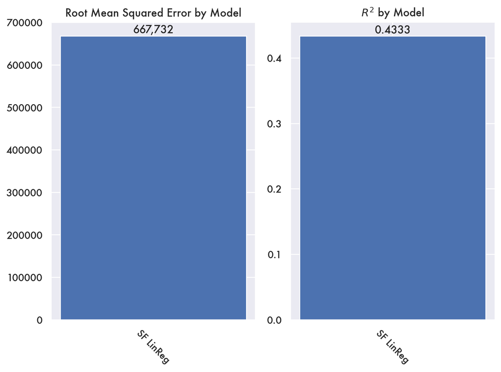

```python
ols_model = smf.ols(
    formula=f"{target} ~ {feature}", data=lr_train
)
result = ols_model.fit()

lr_predict = result.predict(lr_test[feature])

lr_y_test = list(lr_test[target])
lr_y_pred = list(lr_predict)

calc_model_stats("SF LinReg", lr_y_test, lr_y_pred)
plot_model_stats(fig_width=8)
```

These statistics give us an initial RMSE and $R^2$. These stats alone tell us that the we have a relationship between the target and feature. This is a good starting point to compare against other models.

# 4 Forward Selection

Our next model builds on the single feature linear regression by adding more feature. We begin by finding the single feature model with the highest $R^2$ value. Then we add one feature at a time and calculate the $R^2$ value. We note the maximum $R^2$ value and continue to build the model until all features have been used. The model with the highest $R^2$ is then used to calculate the statistics for the Forward Selection model.

```python
import statsmodels.formula.api as smf

(
    lr_train,
    lr_test,
) = train_test_split(number_df, test_size=test_size, random_state=random_state)

feature_cols = lr_train.columns.drop(["price"]).to_list()

features = " + ".join(feature_cols)
best_features = []
best_rsquared = []
best_model = []

iterations = len(feature_cols)

for i in range(iterations):
    this_best_features = ""
    this_best_rsquared = 0
    this_best_model = None
    for feature in feature_cols:
        this_feature = " + ".join(best_features + [feature])
        ols_model = smf.ols(
            formula=f"{target} ~ {this_feature}", data=lr_train
        )
        result = ols_model.fit()
        if result.rsquared > this_best_rsquared:
            this_best_rsquared = result.rsquared
            this_best_features = feature
            this_best_model = result

    feature_cols.remove(this_best_features)
    best_features.append(this_best_features)
    best_rsquared.append(this_best_rsquared)
    best_model.append(this_best_model)

best_index = 0
max_rsquared = best_rsquared[0]

for i in range(1, len(best_rsquared)):
    if best_rsquared[i] > max_rsquared:
        max_rsquared = best_rsquared[i]
        best_index = i


print(" + ".join(best_features[0:best_index]))
print(best_rsquared[best_index])
```

```
area + lot_sqft + bathrooms + lotAreaValue
0.47885666166791985
```

```python
lr_predict = best_model[best_index].predict(
    lr_test
)

lr_y_test = list(lr_test[target])
lr_y_pred = list(lr_predict)

calc_model_stats("FS LinReg", lr_y_test, lr_y_pred)

print(best_model[best_index].summary())
```

```
                            OLS Regression Results
==============================================================================
Dep. Variable:                  price   R-squared:                       0.479
Model:                            OLS   Adj. R-squared:                  0.478
Method:                 Least Squares   F-statistic:                     619.3
Date:                Tue, 07 Mar 2023   Prob (F-statistic):               0.00
Time:                        15:15:02   Log-Likelihood:                -49857.
No. Observations:                3376   AIC:                         9.973e+04
Df Residuals:                    3370   BIC:                         9.976e+04
Df Model:                           5
Covariance Type:            nonrobust
================================================================================
                   coef    std err          t      P>|t|      [0.025      0.975]
--------------------------------------------------------------------------------
Intercept     4.369e+04   4.42e+04      0.988      0.323    -4.3e+04     1.3e+05
area           196.1572     11.796     16.630      0.000     173.030     219.284
lot_sqft         0.1770      0.011     16.010      0.000       0.155       0.199
bathrooms     2.391e+05   1.44e+04     16.578      0.000    2.11e+05    2.67e+05
lotAreaValue   -34.9435      3.239    -10.788      0.000     -41.294     -28.593
bedrooms     -8.533e+04   1.33e+04     -6.424      0.000   -1.11e+05   -5.93e+04
==============================================================================
Omnibus:                     2725.611   Durbin-Watson:                   2.012
Prob(Omnibus):                  0.000   Jarque-Bera (JB):            91195.219
Skew:                           3.617   Prob(JB):                         0.00
Kurtosis:                      27.413   Cond. No.                     4.16e+06
==============================================================================

Notes:
[1] Standard Errors assume that the covariance matrix of the errors is correctly specified.
[2] The condition number is large, 4.16e+06. This might indicate that there are
strong multicollinearity or other numerical problems.
```

## 4.1 Single Feature vs. Forward Selection Comparison

Below we compare the RMSE and $R^2$ values of the single feature and forward selection models:

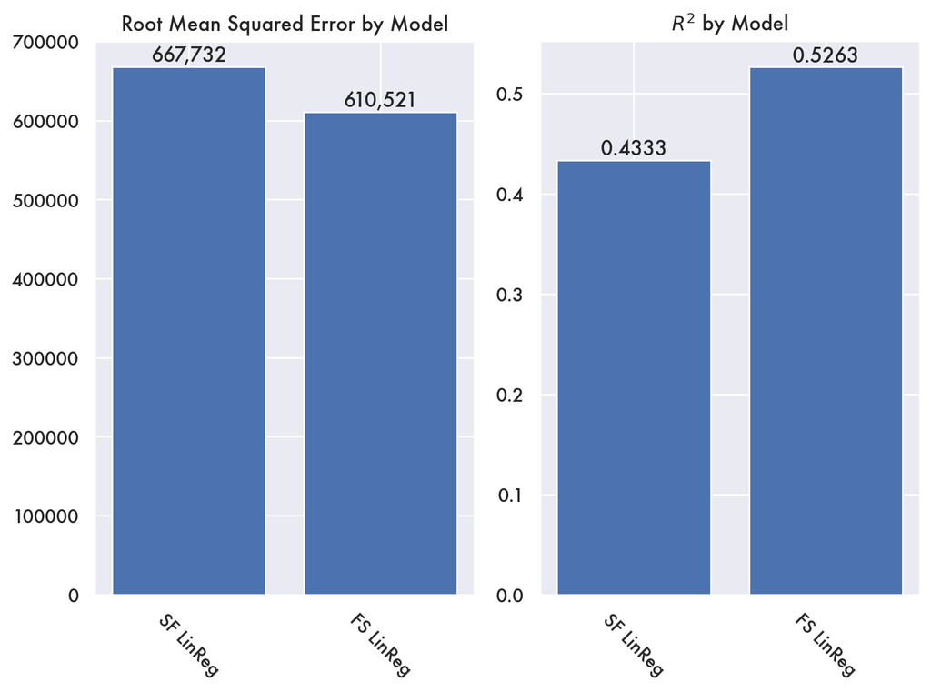

We can see that our forward selection model increases $R^2$ by 21.46%. These results show that forward selection multi feature linear regression produces a more accurate model than single feature linear regression.

# 5 `AdaboostRegressor`

Another option for regression is the `sklearn` `AdaBoostRegressor`. This model has multiple parameters that can be tuned for optimal performance. We are going to focus on `max_estimators` and `max_depth`. In the code below we split the data into training and test sets and calculate $R^2$ vs the number of estimators:

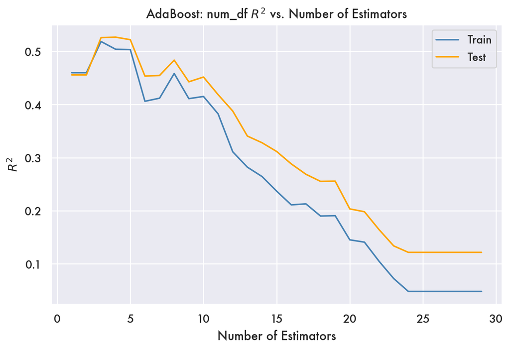

```
0.5268333928345584
4
```

```python
from sklearn.ensemble import AdaBoostRegressor
from sklearn.tree import DecisionTreeRegressor

y_num = number_df[target].values
x_num = number_df.drop(labels=[target], axis=1)

(
    num_train_x,
    num_test_x,
    num_train_y,
    num_test_y,
) = train_test_split(x_num, y_num, test_size=test_size, random_state=random_state)


y_num_bool = number_bool_df[target].values
x_num_bool = number_bool_df.drop(labels=[target], axis=1)

(
    num_bool_train_x,
    num_bool_test_x,
    num_bool_train_y,
    num_bool_test_y,
) = train_test_split(
    x_num_bool, y_num_bool, test_size=test_size, random_state=random_state
)


adaboost_model = AdaBoostRegressor(random_state=42, n_estimators=100).fit(
    num_train_x, num_train_y
)
adaboost_y_pred = adaboost_model.predict(num_test_x)

max_estimators = 30
r_squared_list = []
train_r_squared_list = []
best_r_squared = 0
best_estimator = 0

for i in range(1, max_estimators):
    adaboost_model = AdaBoostRegressor(n_estimators=i, random_state=random_state).fit(
        num_train_x, num_train_y
    )
    adaboost_y_pred = adaboost_model.predict(num_test_x)
    r_squared = r2_score(num_test_y, adaboost_y_pred)
    r_squared_list.append(r_squared)

    if r_squared > best_r_squared:
        best_r_squared = r_squared
        best_estimator = i

    adaboost_y_pred = adaboost_model.predict(num_train_x)
    r_squared = r2_score(num_train_y, adaboost_y_pred)
    train_r_squared_list.append(r_squared)

plt.plot(range(1, max_estimators), train_r_squared_list, color="steelblue", label="Train")
plt.plot(range(1, max_estimators), r_squared_list, color="orange", label="Test")
plt.legend()
plt.xlabel("Number of Estimators")
plt.ylabel("$R^2$")
plt.title("AdaBoost: num_df $R^2$ vs. Number of Estimators")
plt.show()

print(best_r_squared)
print(best_estimator)
```

The above code computes the optimal `n_estimators` for the test data as `4`. There is strong correlation between the train and test data and we can be confident that our `n_estimators` value will produce an optimal result.

In the code below we perform a similar process as above to compute the optimal `DecisionTreeRegressor` `max_depth`.

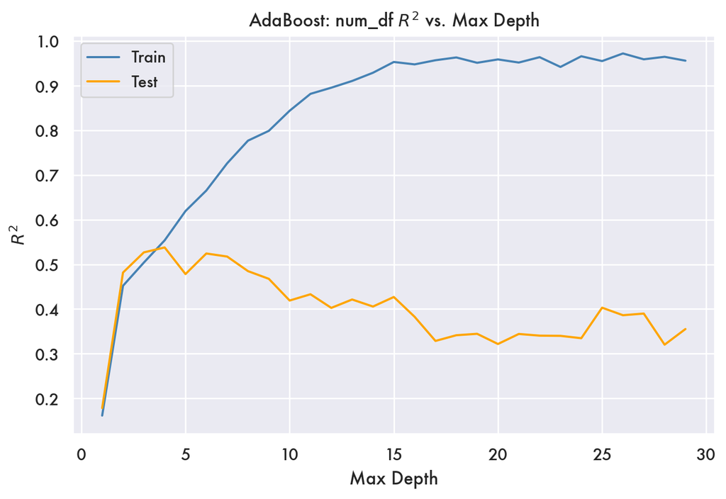

```
Test Best R^2: 0.5378778399853386
Test Best max_depth: 4
```

```python
max_depth = 30
r_squared_list = []
train_r_squared_list = []
best_r_squared = 0
best_depth = 0

for i in range(1, max_depth):
    adaboost_model = AdaBoostRegressor(
        n_estimators=best_estimator,
        random_state=random_state,
        estimator=DecisionTreeRegressor(max_depth=i),
    ).fit(num_train_x, num_train_y)
    adaboost_y_pred = adaboost_model.predict(num_test_x)
    r_squared = r2_score(num_test_y, adaboost_y_pred)
    r_squared_list.append(r_squared)

    if r_squared > best_r_squared:
        best_r_squared = r_squared
        best_depth = i

    adaboost_y_pred = adaboost_model.predict(num_train_x)
    r_squared = r2_score(num_train_y, adaboost_y_pred)
    train_r_squared_list.append(r_squared)


plt.plot(range(1, max_depth), train_r_squared_list, color="steelblue", label="Train")
plt.plot(range(1, max_depth), r_squared_list, color="orange", label="Test")
plt.legend()
plt.xlabel("Max Depth")
plt.ylabel("$R^2$")
plt.title("AdaBoost: num_df $R^2$ vs. Max Depth")
plt.show()

print("Test Best R^2:", best_r_squared)
print("Test Best max_depth:", best_depth)
```

In the visualization above we see a significant divergence between the training and test data sets as we increase `max_depth`. This indicates that the as the model grows in depth it becomes more complex. This complexity leads to overfitting of the test data. To prevent overfitting we will use the best test max depth value of `4`.

```python
adaboost_model = AdaBoostRegressor(
    random_state=42,
    n_estimators=best_estimator,
    estimator=DecisionTreeRegressor(max_depth=best_depth),
).fit(num_train_x, num_train_y)
adaboost_y_pred = adaboost_model.predict(num_test_x)

calc_model_stats("AdaBoost", num_test_y, adaboost_y_pred)
```

```python
adaboost_model = AdaBoostRegressor(
    random_state=42,
    n_estimators=best_estimator,
    estimator=DecisionTreeRegressor(max_depth=best_depth),
).fit(num_bool_train_x, num_bool_train_y)
adaboost_y_pred = adaboost_model.predict(num_bool_test_x)

calc_model_stats("AdaBoost num_bool", num_bool_test_y, adaboost_y_pred)
```

## 5.1 Single Feature vs. Forward Selection vs. AdaBoostRegressor Comparison

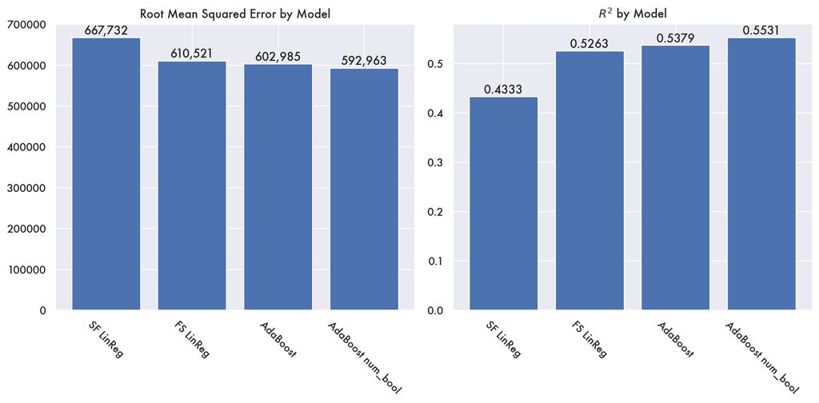

# 6 XGBoost

Our final model will be built using the `xgboost` `XGBRegressor` class. Our goal will be to optimize the hyperparameters of `XGBRegressor` to maximize $R^2$ on the test data set. The `XGBRegressor` is similar to `AdaBoostRegressor` and we will be optimizing the number of estimators (`n_estimators`) and the `max_depth` of the decision tree.

As XGBoost is a flexible modeling tool it can handle boolean values. We will also create another data set containing the boolean values from the original dataframe and compare these against the numbers only dataset.

## 6.1 Feature Importance

XGBoost is similar to RandomForest in that it can show the importance of features. We will use this on both the `num_df` and `num_bool_df` to find the most important features.

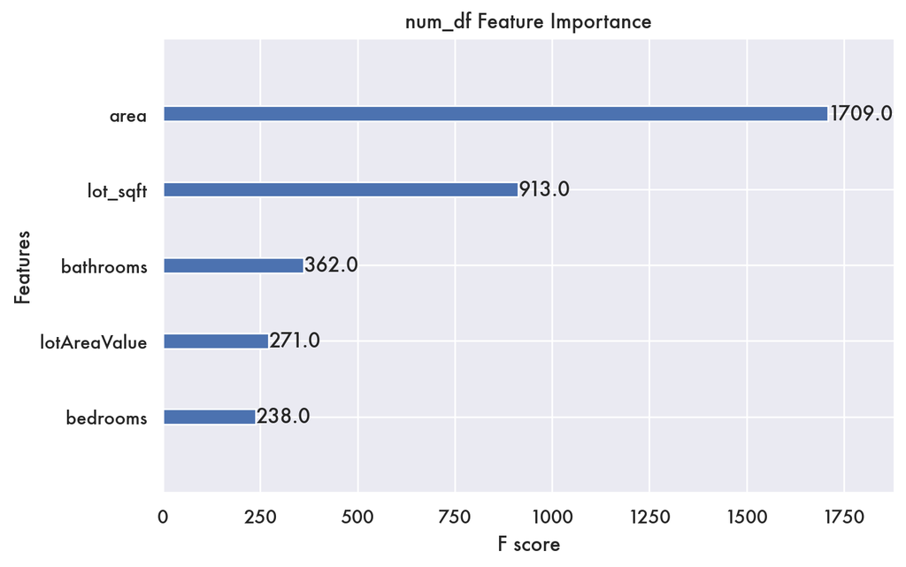

```python
import xgboost as xgb

booster = "gbtree"

xgb_model = xgb.XGBRegressor(n_jobs=1, booster=booster).fit(num_train_x, num_train_y)
y_pred = xgb_model.predict(num_test_x)

xgb.plot_importance(xgb_model, title="num_df Feature Importance")
plt.show()
```

We can also look at our `num_bool_df` dataset to see if there are any boolean features that contribute positively to the prediction accuracy.

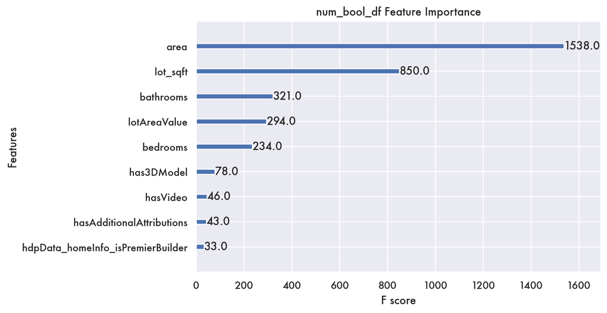

```python
xgb_model = xgb.XGBRegressor(n_jobs=1, booster=booster).fit(num_bool_train_x, num_bool_train_y)
y_pred = xgb_model.predict(num_bool_test_x)

xgb.plot_importance(xgb_model, title="num_bool_df Feature Importance")
plt.show()
```

There may be a small increase in $R^2$ from inclusion of the boolean variables, specifically in features `has3DModel` and `hasVideo`. For now we will focus on the numerical model only

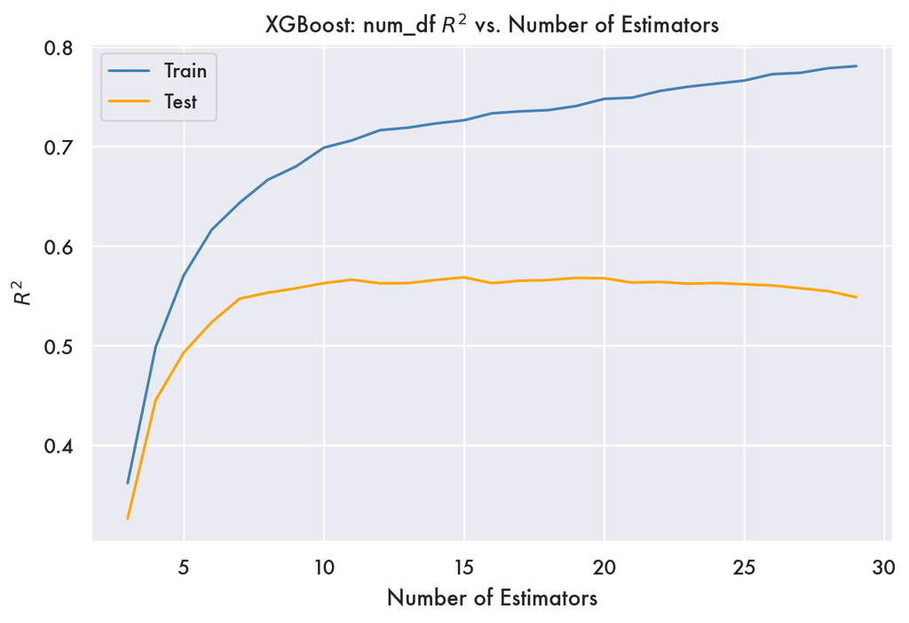

```python
min_estimators = 3
max_estimators = 30
r_squared_list = []
train_r_squared_list = []

for i in range(min_estimators, max_estimators):
    xgb_model = xgb.XGBRegressor(n_estimators=i, random_state=random_state, booster=booster,
            max_depth=5).fit(
        num_train_x, num_train_y
    )
    xgb_y_pred = xgb_model.predict(num_test_x)
    r_squared_list.append(r2_score(num_test_y, xgb_y_pred))

    xgb_y_pred = xgb_model.predict(num_train_x)
    train_r_squared_list.append(r2_score(num_train_y, xgb_y_pred))

plt.plot(
    range(min_estimators, max_estimators),
    train_r_squared_list,
    color="steelblue",
    label="Train",
)
plt.plot(
    range(min_estimators, max_estimators), r_squared_list, color="orange", label="Test"
)
plt.legend()
plt.xlabel("Number of Estimators")
plt.ylabel("$R^2$")
plt.title("XGBoost: num_df $R^2$ vs. Number of Estimators")
plt.show()
```

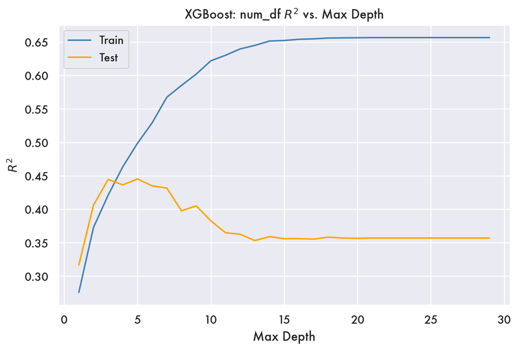

```
0.44526716585928416
5
```

```python
max_depth = 30
r_squared_list = []
train_r_squared_list = []
best_depth = 0
best_r_squared = 0

for i in range(1, max_depth):
    xgb_model = xgb.XGBRegressor(max_depth=i, n_estimators=best_estimator,
            random_state=random_state, booster=booster).fit(
        num_train_x, num_train_y
    )
    xgb_y_pred = xgb_model.predict(num_test_x)
    r_squared = r2_score(num_test_y, xgb_y_pred)
    r_squared_list.append(r_squared)

    if r_squared > best_r_squared:
        best_r_squared = r_squared
        best_depth = i

    xgb_y_pred = xgb_model.predict(num_train_x)
    r_squared = r2_score(num_train_y, xgb_y_pred)
    train_r_squared_list.append(r_squared)

plt.plot(range(1, max_estimators), train_r_squared_list, color="steelblue", label="Train")
plt.plot(range(1, max_estimators), r_squared_list, color="orange", label="Test")
plt.legend()
plt.xlabel("Max Depth")
plt.ylabel("$R^2$")
plt.title("XGBoost: num_df $R^2$ vs. Max Depth")
plt.show()
print(best_r_squared)
print(best_depth)

xgb_model = xgb.XGBRegressor(n_estimators=best_estimator, max_depth=best_depth, booster=booster).fit(num_train_x, num_train_y)
y_pred = xgb_model.predict(num_test_x)

calc_model_stats("XGBoost", num_test_y, y_pred)
```

We will also build a model on the `num_bool` `DataFrame`, passing the calculated depth and estimator values for `max_depth` and `n_estimators`. Will the addition of the boolean features increase $R^2$?

```python
xgb_model = xgb.XGBRegressor(n_estimators=best_estimator, max_depth=best_depth, booster=booster).fit(num_bool_train_x, num_bool_train_y)
y_pred = xgb_model.predict(num_bool_test_x)

calc_model_stats("XGBoost num_bool", num_bool_test_y, y_pred)
```

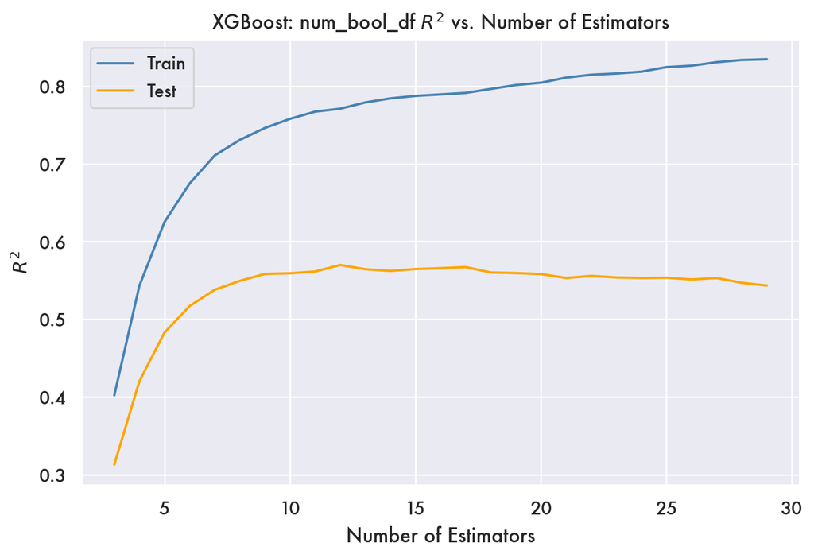

```
0.5698134225344937
12
```

```python
min_estimators = 3
max_estimators = 30
r_squared_list = []
train_r_squared_list = []
best_estimator = 0
best_r_squared = 0

for i in range(min_estimators, max_estimators):
    xgb_model = xgb.XGBRegressor(n_estimators=i, random_state=random_state, booster=booster).fit(
        num_bool_train_x, num_bool_train_y
    )
    xgb_y_pred = xgb_model.predict(num_bool_test_x)
    r_squared = r2_score(num_bool_test_y, xgb_y_pred)
    r_squared_list.append(r_squared)

    if r_squared > best_r_squared:
        best_r_squared = r_squared
        best_estimator = i

    xgb_y_pred = xgb_model.predict(num_bool_train_x)
    r_squared = r2_score(num_bool_train_y, xgb_y_pred)
    train_r_squared_list.append(r_squared)

plt.plot(
    range(min_estimators, max_estimators),
    train_r_squared_list,
    color="steelblue",
    label="Train",
)
plt.plot(
    range(min_estimators, max_estimators), r_squared_list, color="orange", label="Test"
)
plt.legend()
plt.xlabel("Number of Estimators")
plt.ylabel("$R^2$")
plt.title("XGBoost: num_bool_df $R^2$ vs. Number of Estimators")
plt.show()
print(best_r_squared)
print(best_estimator)
```

## 6.2 Final Model Comparison

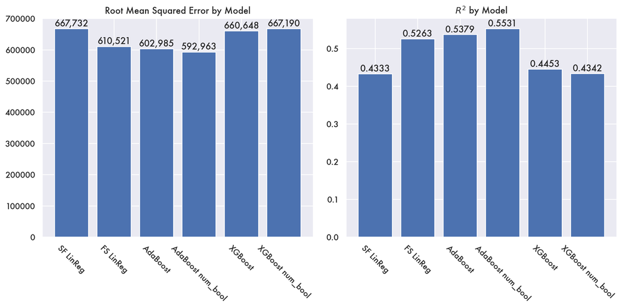

Interestingly we see that `XGBRegressor` performs significantly worse that `AdaBoostRegressor`. This is most likely to be due to a failure to tune the model parameters correctly. This may also be a factor data selected in the test and train data sets. It may be worthwhile to optimize xgboost further, but that falls outside the scope of this project.

# 7 Conclusion

1. Single Feature Linear Regression
2. Forward Selection Linear Regression
3. `AdaBoostRegressor`
   - Optimized `n_estimators` and `max_depth`
   - Compared number only dataset vs number and boolean dataset
4. `XGBRegressor`
   - Optimized `n_estimators` and `max_depth`
   - Compared number only dataset vs number and boolean dataset

From these models we concluded that `AdaBoostRegressor` with the `num_bool_df` resulted in the highest $R^2$ value and the lowest RMSE.

We also used `xbg.plot_importance` to visualize the feature importance and found `area` and `lot_sqft` to be the most important features for predicting price.

From all we can learn that many different modeling methods can produce similar results on a real world data set. There are more variables with more complex modeling methods (`AdaBoostRegressor` and `XGBRegressor`) which may cause them to perform better or worse depending on the input parameters. In practice it is necessary to understand and optimize hyperparameters. This requires a strong understanding of both the hyperparameters and the underlying model. We find that this project provides a good starting point for further price prediction modeling.